# Behavioral Risk Factor Surveillance System Analysis

Michael McGee

## Setup

```r
library(tidyverse)
library(readxl)
library(ggmosaic) # For mosaic plotting
library(usmap) # For US Map plotting
library(usmapdata) # For centroid locations of US map to map geom_text
library(tidycensus) # For population and FIPS data
library(thematic) # Adapt plots to RMD theme
thematic_rmd()

library(showtext) # To customize fonts in ggplot
showtext_auto(enable = TRUE)
font_add_google("Raleway", family = "raleway")
font_add_google("Bebas Neue", family = "bebas neue")
```

## Scope of Data

[figure not shown]

The Behavioral Risk Factor Surveillance System (BRFSS) is a data set from an observational study conducted in 2013 by the CDC in all 50 US states and the District of Columbia, Puerto Rico, and Guam. The purpose of this study was to retrieve state-specific data on preventative health practices and risk behaviors from approximately 490,000 randomly selected individuals that reside in private residences or college housing. The survey was conducted with stratified random sampling from all participating districts.

This survey data allows the ability to ask research questions that we can generalize to the US population. However we can not make any causal statements or inferences based upon this data because it was strictly an observational study and no random assignment was conducted.

Potential non-response bias may be considered for this data since the surveys were conducted using land lines and cell phones. We also know that there is a population of those who do not have neither land lines or cell phones and that those individuals may be at the lower end of the income range.

Since the dataset contains 491,775 rows and 2,365 columns - the data frame for this analysis will only be loaded with columns pertaining to housing, location and vehicular behavior data.

The full codebook PDF for the 2013 BRFSS dataset can be found [**here.**](https://www.cdc.gov/brfss/annual_data/2013/pdf/CODEBOOK13_LLCP.pdf)

## Research Questions

**Research Question 1:** What are the probabilities of owning or renting a home given an individual’s income level and education level?

**Research Question 2:** How do property values influence home ownership or renter status among each US State?

**Research Question 3:** What is the correlation between individuals who claim to “always” wear seat belts and their states’ vehicle fatality rates?

## Research Question 1

**What are the probabilities of owning or renting a home given an individual’s income level and education level?**

### EDA

```r
brfss2013 <- read_csv("Data/brfss13.csv")
```

#### 3 Variables

**`renthom1`: Home owners, renters, and “other arrangement”**

- `n` = Number of respondents
- `pc` = Percentage of total survey

```r
brfss2013 %>% count(renthom1) %>% summarize(renthom1, n, pc = n/sum(n)) %>% arrange(desc(pc))
```

```
## # A tibble: 4 × 3
##   renthom1               n     pc
##   <chr>              <int>  <dbl>
## 1 Own               351636 0.715
## 2 Rent              110980 0.226
## 3 Other arrangement  20711 0.0421
## 4 <NA>                8448 0.0172
```

**`X_educag`: Education Levels (4 levels)**

- `n` = Number of respondents
- `pc` = Percentage of total survey

```r
brfss2013 %>% count(X_educag) %>% summarize(X_educag, n, pc = n/sum(n))
```

```
## # A tibble: 5 × 3
##   X_educag                                        n      pc
##   <chr>                                       <int>   <dbl>
## 1 Attended college or technical school       134196 0.273
## 2 Did not graduate high school                42213 0.0858
## 3 Graduated from college or technical school 170118 0.346
## 4 Graduated high school                      142968 0.291
## 5 <NA>                                         2280 0.00464
```

**`income2`: Income Levels (8 classes)**

- `n` = Number of respondents
- `pc` = Percentage of total survey

```r
brfss2013 %>% count(income2) %>% summarize(income2, n, pc = n/sum(n))
```

```
## # A tibble: 9 × 3
##   income2                n     pc
##   <chr>              <int>  <dbl>
## 1 $75,000 or more   115902 0.236
## 2 Less than $10,000  25441 0.0517
## 3 Less than $15,000  26794 0.0545
## 4 Less than $20,000  34873 0.0709
## 5 Less than $25,000  41732 0.0849
## 6 Less than $35,000  48867 0.0994
## 7 Less than $50,000  61509 0.125
## 8 Less than $75,000  65231 0.133
## 9 <NA>               71426 0.145
```

#### Data Wrangling

Create a new data frame and rename with the 3 variables selected for this analysis and remove any NA’s.

```r
ds <- brfss2013 %>% select(income2, X_educag, renthom1) %>%
  rename(income_lev = income2, edu_lev = X_educag) %>%
  drop_na()

ds %>% head()
```

```
## # A tibble: 6 × 3
##   income_lev        edu_lev                                    renthom1
##   <chr>             <chr>                                      <chr>
## 1 Less than $75,000 Graduated from college or technical school Own
## 2 $75,000 or more   Attended college or technical school       Own
## 3 $75,000 or more   Graduated from college or technical school Own
## 4 Less than $75,000 Graduated high school                      Own
## 5 Less than $50,000 Graduated from college or technical school Own
## 6 $75,000 or more   Graduated from college or technical school Own
```

Relabel income values with numeric labels.

```r
ds <- ds %>% mutate(income_lev = as.factor(case_when(
  income_lev == "Less than $10,000" ~ "$0 - $10,000",
  income_lev == "Less than $15,000" ~ "$10,000 - $15,000",
  income_lev == "Less than $20,000" ~ "$15,000 - $20,000",
  income_lev == "Less than $25,000" ~ "$20,000 - $25,000",
  income_lev == "Less than $35,000" ~ "$25,000 - $35,000",
  income_lev == "Less than $50,000" ~ "$35,000 - $50,000",
  income_lev == "Less than $75,000" ~ "$50,000 - $75,000",
  income_lev == "$75,000 or more"   ~ "$75,000 +"    ) ) )
```

Verify factor levels

```r
ds$edu_lev <- factor(ds$edu_lev, levels = c("Did not graduate high school", "Graduated high school",
                                            "Attended college or technical school", "Graduated from college or technical school"))
```

```r
levels(ds$edu_lev)
```

```
## [1] "Did not graduate high school"
## [2] "Graduated high school"
## [3] "Attended college or technical school"
## [4] "Graduated from college or technical school"
```

```r
levels(ds$income_lev)
```

```
## [1] "$0 - $10,000"      "$10,000 - $15,000" "$15,000 - $20,000"
## [4] "$20,000 - $25,000" "$25,000 - $35,000" "$35,000 - $50,000"
## [7] "$50,000 - $75,000" "$75,000 +"
```

#### Frequency Histograms for the 3 Variables

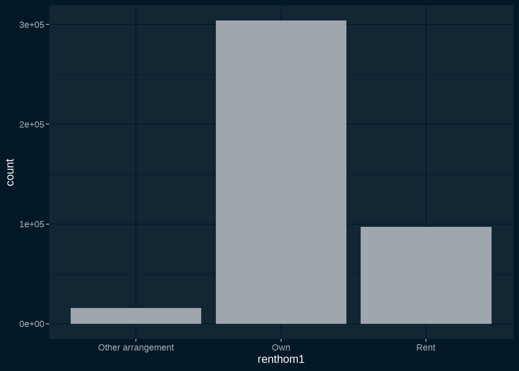

```r
ds %>% ggplot(aes(x = renthom1)) +
  geom_bar()
```

> `renthom1` - Home Residence Status shows that home owners comprised more than double the amount of “rent” and “other arrangement” responses.

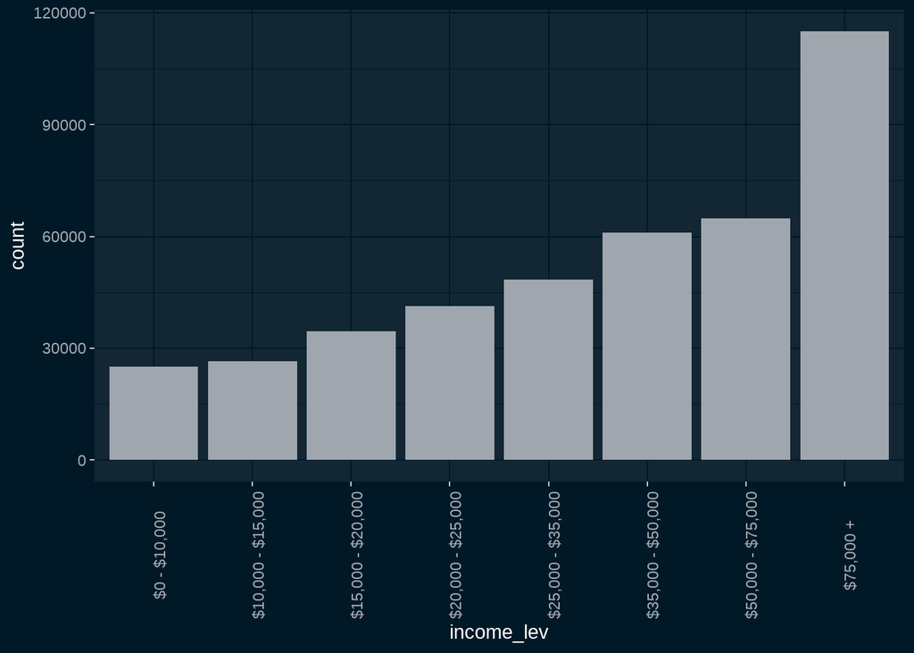

```r
ds %>% ggplot(aes(x = income_lev)) +
  geom_bar() +
  theme(axis.text.x = element_text(angle = 90))
```

> `income_lev` - Income levels of respondents is highly left skewed. Respondents over the $75,000 threshold almost doubles those in the $50,000-$75,000 range and decreases continuously down the income ranges.

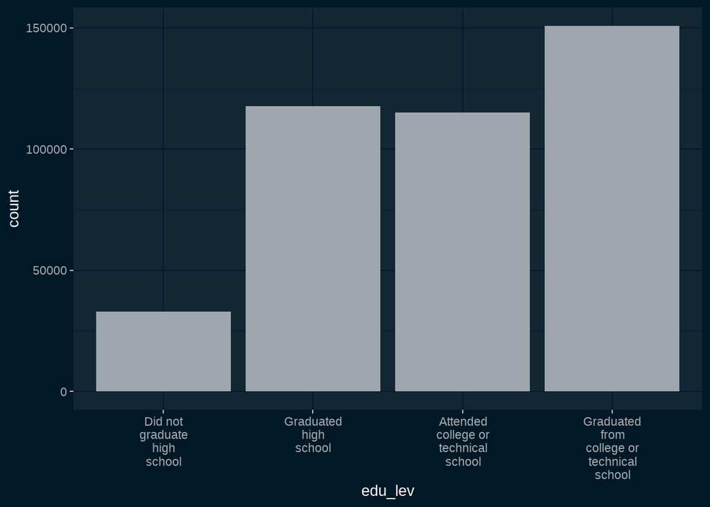

```r
ds %>% ggplot(aes(x = edu_lev)) +
  geom_bar() +                                # Modify labels of ggplot2 barplot
  scale_x_discrete(labels = function(x) str_wrap(levels(ds$edu_lev), width = 10))
```

> `edu_lev` - Education levels above “Did not graduate high school” make up 92% of respondents with “College graduates” taking about 20% more than the two median education levels.

### Mapping for Mosaic Plots

Mosaic plots will show how education and income levels vary for each of the 3 residence types (own, rent, & other).

Each plot will display a weighted percentile label inside each box of the mosaic plot. The first step is to build a data frame using `ggplot_build()` to locate all of the box coordinates to tell ggplot where to map the percentiles on the plot. Since we have 4 education levels and 8 income levels, we will obtain 32 boxes for each of the 3 mosaic plots.

```r
# Calculate percentiles and X/Y locations by (own/rent/other)
gg_own <- ggplot_build(ds %>% filter(renthom1 == "Own") %>% ggplot() +
  geom_mosaic(aes(x=product(edu_lev, income_lev), fill = edu_lev)))$data[[1]] %>%
  summarize(pc = .wt/sum(.wt), label, xmin, xmax, ymin, ymax, .wt) %>% ungroup()

gg_rent <- ggplot_build(ds %>% filter(renthom1 == "Rent") %>% ggplot() +
  geom_mosaic(aes(x=product(edu_lev, income_lev), fill = edu_lev)))$data[[1]] %>%
  summarize(pc = .wt/sum(.wt), label, xmin, xmax, ymin, ymax, .wt) %>% ungroup()

gg_other <- ggplot_build(ds %>% filter(renthom1 == "Other arrangement") %>% ggplot() +
  geom_mosaic(aes(x=product(edu_lev, income_lev), fill = edu_lev)))$data[[1]] %>%
  summarize(pc = .wt/sum(.wt), label, xmin, xmax, ymin, ymax, .wt) %>% ungroup()
```

We now have the percentiles of each combination of income and education (8x4=32) for each residence type in the `pc` column, and the mapping in the `xmin`, `xmax`, `ymin`, `ymax` columns.

Next, aggregate these individual percentiles into their marginal probabilities for income and education levels.

This function creates a data frame that calculates the marginal probabilities, and maps them to the centroid of `x` and `y` for `geom_label` `aes`.

```r
geom_text_margin <- function(Own_Rent_Other_arrangement){ # Enter "Own", "Rent", or "Other arrangement"

r <- ggplot_build(ds %>% filter(renthom1 == Own_Rent_Other_arrangement) %>%
               ggplot() + # Create gg_build object to give coordinates
               geom_mosaic(aes(x=product(edu_lev, income_lev), fill = edu_lev)) +
               ggtitle(Own_Rent_Other_arrangement) +
               ylab("Education Level") +
               xlab("Income Level") +
               theme(axis.text.x = element_text(angle = 75, vjust = 0.5, hjust=0.5, size = 10, face = "bold"),
                     axis.text.y = element_blank(),
                     legend.position = "left",
                     legend.key.height = unit(100, "points"),
                     legend.title = element_blank(),
                     plot.title.position = "plot",
                     plot.title = element_text(hjust = 0.5, size = 28, face = "bold"),
                     axis.title = element_text(face = "bold", size = 15)) +
               guides(fill = guide_legend(reverse=TRUE))) %>% .[[1]] %>% .[[1]] %>% # Pull out the data frame
  mutate(x = case_when( # Add x and y columns by averaging min and max coordiantes to get center
      x__income_lev == "$0 - $10,000"      & x__fill__edu_lev == "Did not graduate high school" ~ (xmin+xmax)/2,
      x__income_lev == "$10,000 - $15,000" & x__fill__edu_lev == "Did not graduate high school" ~ (xmin+xmax)/2,
      x__income_lev == "$15,000 - $20,000" & x__fill__edu_lev == "Did not graduate high school" ~ (xmin+xmax)/2,
      x__income_lev == "$20,000 - $25,000" & x__fill__edu_lev == "Did not graduate high school" ~ (xmin+xmax)/2,
      x__income_lev == "$25,000 - $35,000" & x__fill__edu_lev == "Did not graduate high school" ~ (xmin+xmax)/2,
      x__income_lev == "$35,000 - $50,000" & x__fill__edu_lev == "Did not graduate high school" ~ (xmin+xmax)/2,
      x__income_lev == "$50,000 - $75,000" & x__fill__edu_lev == "Did not graduate high school" ~ (xmin+xmax)/2,
      x__income_lev == "$75,000 +"         & x__fill__edu_lev == "Did not graduate high school" ~ (xmin+xmax)/2),
         y = case_when(
      x__fill__edu_lev == "Did not graduate high school" & x__income_lev == "$75,000 +" ~ (ymin+ymax)/2,
      x__fill__edu_lev == "Attended college or technical school" & x__income_lev == "$75,000 +" ~ (ymin+ymax)/2,
      x__fill__edu_lev == "Did not graduate high school" & x__income_lev == "$75,000 +" ~ (ymin+ymax)/2,
      x__fill__edu_lev == "Graduated from college or technical school" & x__income_lev == "$75,000 +" ~ (ymin+ymax)/2,
      x__fill__edu_lev == "Graduated high school" & x__income_lev == "$75,000 +" ~ (ymin+ymax)/2)
               ) %>%
  mutate(x = if_else(is.na(x),1,x), # Force income_lev marginals against the x axis
         y = if_else(is.na(y),1,y)  # Force edu_level marginals against the y axis
  ) %>%
  mutate(pc = .wt/sum(.wt)) # Add percentile of each 32 possibilities (pc)

# Create marginal table of column sums
cat_inc <- r %>% group_by(x__income_lev) %>% summarize(wt_pc = sum(pc))
cat_edu <- r %>% group_by(x__fill__edu_lev) %>% summarize(wt_pc = sum(pc))
colnames(cat_inc) <- c("cat", "wt_pc")
colnames(cat_edu) <- c("cat", "wt_pc")
cat <- full_join(cat_edu, cat_inc)


# Merge r and cat manually
cat <- cat %>%
  mutate(
        x = case_when( # Map centroid x values to income_lev, edu_lev will be 1
cat == "Did not graduate high school"               ~ 1,
cat == "Graduated high school"                      ~ 1,
cat == "Attended college or technical school"       ~ 1,
cat == "Graduated from college or technical school" ~ 1,
cat == "$0 - $10,000"                               ~ r[r$label == "Did not graduate high school\n$0 - $10,000", "x"],
cat == "$10,000 - $15,000"                          ~ r[r$label == "Did not graduate high school\n$10,000 - $15,000", "x"],
cat == "$15,000 - $20,000"                          ~ r[r$label == "Did not graduate high school\n$15,000 - $20,000", "x"],
cat == "$20,000 - $25,000"                          ~ r[r$label == "Did not graduate high school\n$20,000 - $25,000", "x"],
cat == "$25,000 - $35,000"                          ~ r[r$label == "Did not graduate high school\n$25,000 - $35,000", "x"],
cat == "$35,000 - $50,000"                          ~ r[r$label == "Did not graduate high school\n$35,000 - $50,000", "x"],
cat == "$50,000 - $75,000"                          ~ r[r$label == "Did not graduate high school\n$50,000 - $75,000", "x"],
cat == "$75,000 +"                                  ~ r[r$label == "Did not graduate high school\n$75,000 +", "x"]
                      ),
        y = case_when( # Map centroid y values to edu_lev, income_lev will be 1
cat == "Did not graduate high school"               ~ r[r$label == "Did not graduate high school\n$75,000 +", "y"],
cat == "Graduated high school"                      ~ r[r$label == "Graduated high school\n$75,000 +", "y"],
cat == "Attended college or technical school"       ~ r[r$label == "Attended college or technical school\n$75,000 +", "y"],
cat == "Graduated from college or technical school" ~ r[r$label == "Graduated from college or technical school\n$75,000 +", "y"],
cat == "$0 - $10,000"                               ~ 1,
cat == "$10,000 - $15,000"                          ~ 1,
cat == "$15,000 - $20,000"                          ~ 1,
cat == "$20,000 - $25,000"                          ~ 1,
cat == "$25,000 - $35,000"                          ~ 1,
cat == "$35,000 - $50,000"                          ~ 1,
cat == "$50,000 - $75,000"                          ~ 1,
cat == "$75,000 +"                                  ~ 1
                      )
        )
cat
}
```

### Mosaic Plots of Income & Education Levels by Residence Status

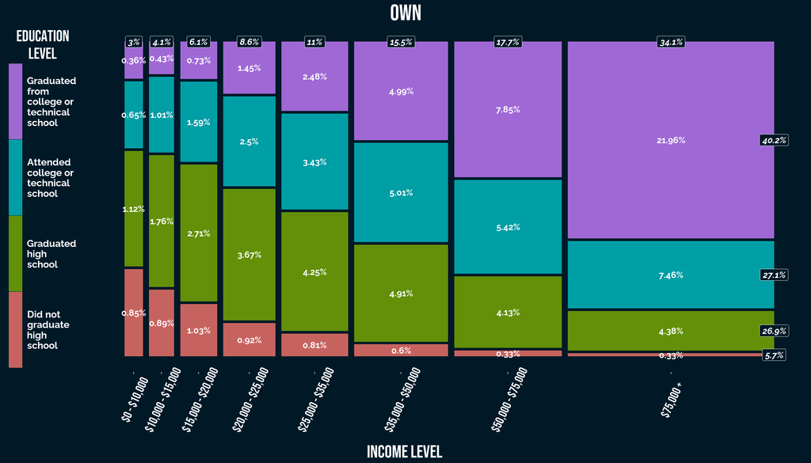

```r
ds %>% filter(renthom1 == "Own") %>% ggplot() +
  geom_mosaic(aes(x=product(edu_lev, income_lev), fill = edu_lev)) +
  ggtitle("Own") +
  xlab("Income Level") +
  scale_fill_discrete(labels = function(x) str_wrap(x, width = 10)) +
  theme(axis.text.x = element_text(color = "white", size = 15, angle = 65, vjust = 0.65, hjust=0.5,
                                   face = "bold", family = "bebas neue"),
        axis.text.y = element_blank(),
        axis.ticks.y = element_blank(),
        axis.title.y = element_blank(),
        axis.title.x = element_text(size = 22, hjust = 0.43, family = "bebas neue"),
        legend.position = "left",
        legend.justification = c(-1, 0.25),
        legend.key.height = unit(95, "points"),
        legend.text = element_text(size = 12, face = "bold", family = "raleway"),
        legend.title = element_text(face = "bold", size = 20, hjust = 0.5, family = "bebas neue"),
        plot.title.position = "plot",
        plot.title = element_text(hjust = 0.5, size = 28, face = "bold", family = "bebas neue"),
        axis.title = element_text(face = "bold", size = 18),
        panel.grid.major = element_blank(),
        panel.grid.minor = element_blank(),
        panel.background = element_blank()) +
  guides(fill = guide_legend(title="Education\nLevel", reverse=TRUE),
         colour = guide_legend(nrow = 2)) +
  geom_text(data = gg_own, # Individual percentiles
            aes(x = (xmin+xmax)/2, y = (ymin+ymax)/2, # min+max/2 gives the center location to the mapping
                label = paste0(round(pc, 4)*100,"%")), # Multiply % by 100, round, and add % symbol
            fontface = "bold",
            family = "raleway") +
  geom_label(data = geom_text_margin("Own"), # Marginal probabilities
             aes(x = x, y = y,
                 label = paste0(round(wt_pc*100, 1),"%")),
             fontface="bold.italic",
             family = "raleway")
```

> - Home owner’s income levels are highly left skewed with the top half of income levels comprising over 77% of responses for home owners. Notice how wide the vertical bars on the right side of the chart are.
> - Home owner’s education levels are also highly left skewed with over 67% of respondents reporting education in the top half of the four education levels. Note the higher presence of purple and blue in the chart compared to green (27%) and red (5.7%).

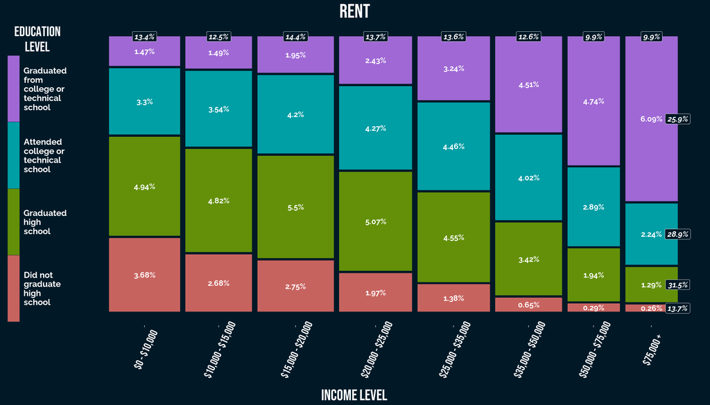

```r
ds %>% filter(renthom1 == "Rent") %>% ggplot() +
  geom_mosaic(aes(x=product(edu_lev, income_lev), fill = edu_lev)) +
  ggtitle("Rent") +
  ylab("Education Level") +
  xlab("Income Level") +
  scale_fill_discrete(labels = function(x) str_wrap(x, width = 10)) +
    theme(axis.text.x = element_text(color = "white", size = 15, angle = 65, vjust = 0.65, hjust=0.5,
                                   face = "bold", family = "bebas neue"),
        axis.text.y = element_blank(),
        axis.ticks.y = element_blank(),
        axis.title.y = element_blank(),
        axis.title.x = element_text(size = 22, hjust = 0.43, family = "bebas neue"),
        legend.position = "left",
        legend.justification = c(-1, 0.25),
        legend.key.height = unit(95, "points"),
        legend.text = element_text(size = 12, face = "bold", family = "raleway"),
        legend.title = element_text(face = "bold", size = 20, hjust = 0.5, family = "bebas neue"),
        plot.title.position = "plot",
        plot.title = element_text(hjust = 0.5, size = 28, face = "bold", family = "bebas neue"),
        axis.title = element_text(face = "bold", size = 18),
        panel.grid.major = element_blank(),
        panel.grid.minor = element_blank(),
        panel.background = element_blank()) +
  guides(fill = guide_legend(title="Education\nLevel", reverse=TRUE),
         colour = guide_legend(nrow = 2)) +
  geom_text(data = gg_rent, # Individual percentiles
            aes(x = (xmin+xmax)/2, y = (ymin+ymax)/2, # min+max/2 gives the center location to the mapping
                label = paste0(round(pc, 4)*100,"%")), # Multiply % by 100, round, and add % symbol
            fontface = "bold",
            family = "raleway") +
  geom_label(data = geom_text_margin("Rent"), # Marginal probabilities
             aes(x = x, y = y,
                 label = paste0(round(wt_pc*100, 1),"%")),
             fontface="bold.italic",
             family = "raleway")
```

> - Rental respondents report having a much more unimodal distribution in income levels with a tight range of 9.9%-14.4%. However the lower bound of the distribution range does fall on the highest income levels, and the upper bound falls on the lower end of income levels. This indicates that while this distribution appears unimodal, it is skewed in the opposite direction from the home owner’s income levels.
> - Renters education levels follow a similar distribution as the home owners however the entire distribution shifts downward with the top education level shrinking by nearly half (40% to 26%), and the lowest education level more than doubling (5.7% to 13.7%).

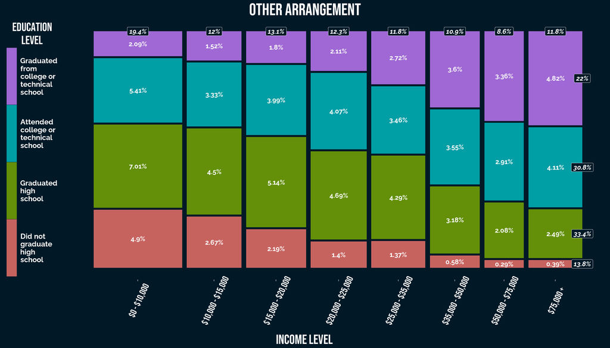

```r
ds %>% filter(renthom1 == "Other arrangement") %>% ggplot() +
  geom_mosaic(aes(x=product(edu_lev, income_lev), fill = edu_lev)) +
  ggtitle("Other Arrangement") +
  ylab("Education Level") +
  xlab("Income Level") +
  scale_fill_discrete(labels = function(x) str_wrap(x, width = 10)) +
  theme(axis.text.x = element_text(color = "white", size = 15, angle = 65, vjust = 0.65, hjust=0.5,
                                   face = "bold", family = "bebas neue"),
        axis.text.y = element_blank(),
        axis.ticks.y = element_blank(),
        axis.title.y = element_blank(),
        axis.title.x = element_text(size = 22, hjust = 0.43, family = "bebas neue"),
        legend.position = "left",
        legend.justification = c(-1, 0.25),
        legend.key.height = unit(95, "points"),
        legend.text = element_text(size = 12, face = "bold", family = "raleway"),
        legend.title = element_text(face = "bold", size = 20, hjust = 0.5, family = "bebas neue"),
        plot.title.position = "plot",
        plot.title = element_text(hjust = 0.5, size = 28, face = "bold", family = "bebas neue"),
        axis.title = element_text(face = "bold", size = 18),
        panel.grid.major = element_blank(),
        panel.grid.minor = element_blank(),
        panel.background = element_blank()) +
  guides(fill = guide_legend(title="Education\nLevel", reverse=TRUE),
         colour = guide_legend(nrow = 2)) +
  geom_text(data = gg_other, # Individual percentiles
            aes(x = (xmin+xmax)/2, y = (ymin+ymax)/2, # min+max/2 gives the center location to the mapping
                label = paste0(round(pc, 4)*100,"%")), # Multiply % by 100, round, and add % symbol
            fontface = "bold",
            family = "raleway") +
  geom_label(data = geom_text_margin("Other arrangement"), # Marginal probabilities
             aes(x = x, y = y,
                 label = paste0(round(wt_pc*100, 1),"%")),
             fontface="bold.italic",
             family = "raleway")
```

### Probabilities of Owning/Renting/Other given Income & Education Levels

- The probabilities calculated in the script below are as follows:
  - P(A) - Home Residence Status: Own, Rent, or Othe Arrangement
  - P(B|A) - Income Level: ($0-$10,000, $10,000-$15,000, $15,000-$20,000, $20,000-$25,000, $25,000-$35,000, $35,000-$50,000 $50,000-$75,000, $75,000 +), given Home Residence Status.
  - P(C|A&B) - Education Level: (Did not graduate high school, Graduated high school, Attended college or technical school, Graduated from college or technical school), given Home Residence Status and Income Level.
  - P(A|B&C) - Probability of Home Residence Status given Income Level and Education Level.

```r
options(digits = 4)

# P(A) - Marginal Probability of Home Residence Status (Home, Rent, and Other) ---
p_A <- ds %>% group_by(renthom1) %>% summarise(n = n(), p = n/nrow(.))

# P Own
p_A1 <- filter(p_A, renthom1 == "Own") %>% select(p)

# P Rent
p_A2 <- filter(p_A, renthom1 == "Rent") %>% select(p)

# P Other arrangement
p_A3 <- filter(p_A, renthom1 == "Other arrangement") %>% select(p)
# -------------------------------------



# P(B|A) - Conditional Probability of B (income level), given A (home residence status) ---
# Income | Own
p_B1 <- ds %>% filter(renthom1 == "Own") %>% group_by(income_lev) %>% summarise(n = n(), p = n/nrow(.))

# Income |  Rent
p_B2 <- ds %>% filter(renthom1 == "Rent") %>% group_by(income_lev) %>% summarise(n = n(), p = n/nrow(.))

# Income |  Other
p_B3 <- ds %>% filter(renthom1 == "Other arrangement") %>% group_by(income_lev) %>% summarise(n = n(), p = n/nrow(.))
# -------------------------------------



# P(C|A&B) - Conditional Probability of C (education level), given A (home residence status) & B (income level) ---

p_C1 <- { own_edu_inc <- list() # Preallocate list to record each iteration

  for(i in seq_along(unique(ds$income_lev))){ # Filters to residence status and iterates through income levels
  own_edu_inc[[i]] <- ds %>% filter(renthom1 == "Own" & income_lev == levels(ds$income_lev)[i]) %>%
    group_by(edu_lev) %>% summarise(n = n(), p = n/nrow(.)) } # Group by edu_lev to get weights among each income level

own_edu_inc <- setNames(own_edu_inc, levels(ds$income_lev)) # Rename list elements to match income levels
own_edu_inc <- bind_rows(own_edu_inc, .id = "income") # Bind list elements into a data frame with income level names (.id)
}


p_C2 <- { rent_edu_inc <- list()

for(i in seq_along(unique(ds$income_lev))){
  rent_edu_inc[[i]] <- ds %>% filter(renthom1 == "Rent" & income_lev == levels(ds$income_lev)[i]) %>%
    group_by(edu_lev) %>% summarise(n = n(), p = n/nrow(.)) }

rent_edu_inc <- setNames(rent_edu_inc, levels(ds$income_lev))
rent_edu_inc <- bind_rows(rent_edu_inc, .id = "income")
}


p_C3 <- { other_edu_inc <- list()

for(i in seq_along(unique(ds$income_lev))){
  other_edu_inc[[i]] <- ds %>% filter(renthom1 == "Other arrangement" & income_lev == levels(ds$income_lev)[i]) %>%
    group_by(edu_lev) %>% summarise(n = n(), p = n/nrow(.)) }

other_edu_inc <- setNames(other_edu_inc, levels(ds$income_lev))
other_edu_inc <- bind_rows(other_edu_inc, .id = "income")
}

# -------------------------------------



# Joint Probabilities of A∩B∩C  ---

own_proababilities <- p_C1 %>%  # Add p_B values
  left_join(p_B1 %>% select(1,3), by = c("income" = "income_lev"), suffix = c("C", "B")) %>%
  mutate(pA = p_A[1,3]) %>% unnest(pA) %>% rename(pA = p) %>% # Add p_A values
  mutate(joint = pC*pB*pA)  # Create joint probabilities


rent_proababilities <- p_C2 %>%  # Add p_B values
  left_join(p_B2 %>% select(1,3), by = c("income" = "income_lev"), suffix = c("C", "B")) %>%
  mutate(pA = p_A[2,3]) %>% unnest(pA) %>% rename(pA = p) %>% # Add p_A values
  mutate(joint = pC*pB*pA) # Create joint probabilities

other_proababilities <- p_C3 %>%  # Add p_B values
  left_join(p_B3 %>% select(1,3), by = c("income" = "income_lev"), suffix = c("C", "B")) %>%
  mutate(pA = p_A[3,3]) %>% unnest(pA) %>% rename(pA = p) %>% # Add p_A values
  mutate(joint = pC*pB*pA) # Create joint probabilities

# -----------------------------------------



# P(A|B∩C) using loops with Bayes Theorem ---

own_proababilities$A_given_BandC <- 1:nrow(own_proababilities)
for(i in 1:nrow(own_proababilities)){
  own_proababilities$A_given_BandC[i] <- own_proababilities[i, "joint"] /
                 (own_proababilities[i,"joint"] + rent_proababilities[i,"joint"] + other_proababilities[i, "joint"])
}
own_proababilities <- own_proababilities %>% unnest(A_given_BandC)


rent_proababilities$A_given_BandC <- 1:nrow(rent_proababilities)
for(i in 1:nrow(rent_proababilities)){
  rent_proababilities$A_given_BandC[i] <- rent_proababilities[i, "joint"] /
                 (own_proababilities[i,"joint"] + rent_proababilities[i,"joint"] + other_proababilities[i, "joint"])
}
rent_proababilities <- rent_proababilities %>% unnest(A_given_BandC)


other_proababilities$A_given_BandC <- 1:nrow(other_proababilities)
for(i in 1:nrow(other_proababilities)){
  other_proababilities$A_given_BandC[i] <- other_proababilities[i, "joint"] /
    (own_proababilities[i,"joint"] + rent_proababilities[i,"joint"] + other_proababilities[i, "joint"])
}
other_proababilities <- other_proababilities %>% unnest(A_given_BandC)


# -------------------------------------------
```

*Math Help Sources:*

> - https://stats.stackexchange.com/questions/258379/why-is-pa-bc-pbc-pab-c
> - https://stats.stackexchange.com/questions/318674/what-is-pa-b-c-when-b-c-are-both-independent
> - https://stats.stackexchange.com/questions/288260/what-does-pabpac-simplify-to
> - https://ctools.ece.utah.edu/Probability/ConditionalProb/DiscreteRandVars/ProbCondDiscreteEx4.pdf

### Plotting the Probabilities of Home Residence Status

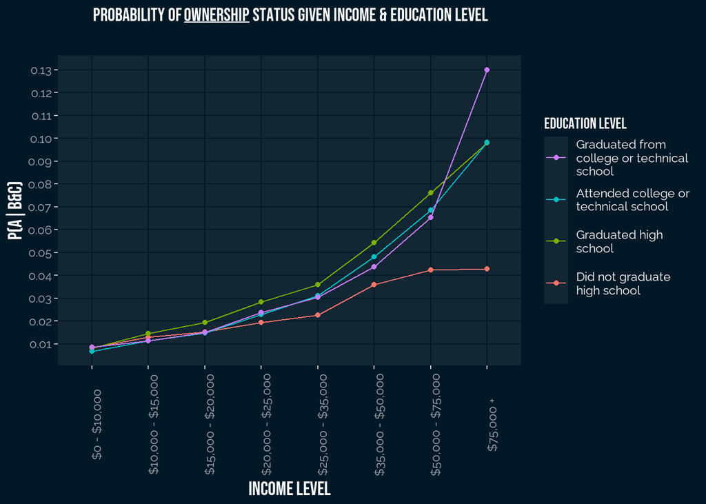

```r
own_proababilities %>% ggplot(aes(x = income, y = A_given_BandC, color = edu_lev, group = edu_lev)) +
  geom_line() +
  geom_point() +
  guides(color = guide_legend(reverse=TRUE)) +
  scale_color_discrete("Education Level") +
  ylab("P(A|B&C)") +
  xlab("Income Level") +
  ggtitle(expression(atop(
    paste("Probability of ", underline("Ownership"), " Status Given Income & Education Level")))) +
  theme(axis.text.x = element_text(angle = 90),
        axis.text = element_text(family = "raleway"),
        axis.title = element_text(family = "bebas neue", size = 14),
        plot.title = element_text(family = "bebas neue", hjust = 0.5),
        legend.title = element_text(family = "bebas neue"),
        legend.text = element_text(family = "raleway"),
        legend.key.height = unit(30, "points"),
        panel.grid.minor = element_blank()) +
  scale_y_continuous(n.breaks = 15) +
  scale_color_discrete(name = "Education Level",
                       labels = function(x) str_wrap(levels(ds$edu_lev), width = 20))
```

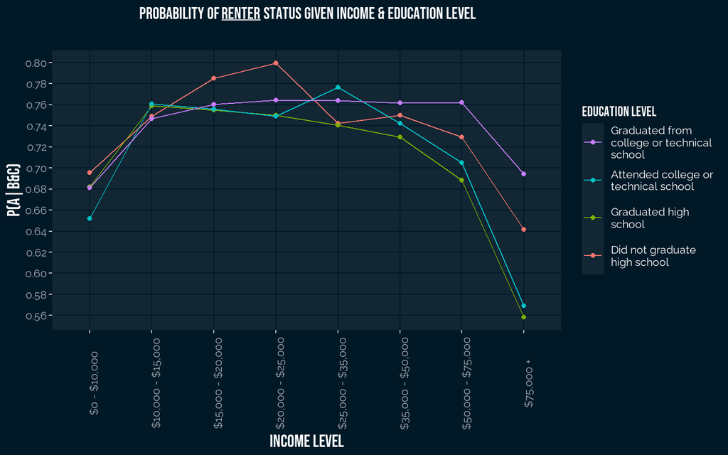

```r
rent_proababilities %>% ggplot(aes(x = income, y = A_given_BandC, color = edu_lev, group = edu_lev)) +
  geom_line() +
  geom_point() +
  guides(color = guide_legend(reverse=TRUE)) +
  scale_color_discrete("Education Level") +
  ylab("P(A|B&C)") +
  xlab("Income Level") +
  ggtitle(expression(atop(
    paste("Probability of ", underline("Renter"), " Status Given Income & Education Level")))) +
  theme(axis.text.x = element_text(angle = 90),
        axis.text = element_text(family = "raleway"),
        axis.title = element_text(family = "bebas neue", size = 14),
        plot.title = element_text(family = "bebas neue", hjust = 0.5),
        legend.title = element_text(family = "bebas neue"),
        legend.text = element_text(family = "raleway"),
        legend.key.height = unit(30, "points"),
        panel.grid.minor = element_blank()) +
  scale_y_continuous(n.breaks = 15) +
  scale_color_discrete(name = "Education Level",
                       labels = function(x) str_wrap(levels(ds$edu_lev), width = 20))
```

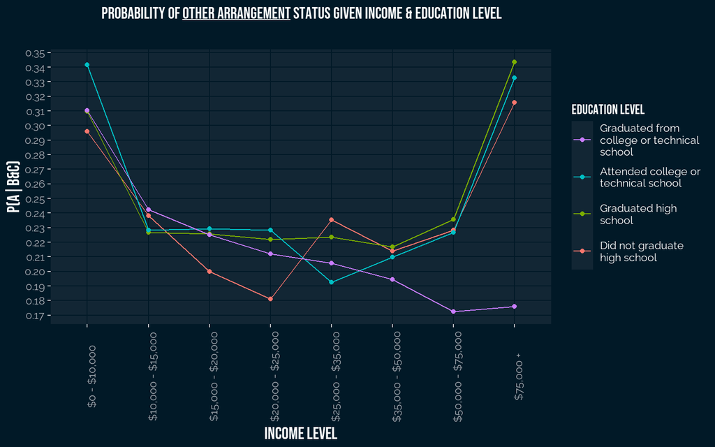

```r
other_proababilities %>% ggplot(aes(x = income, y = A_given_BandC, color = edu_lev, group = edu_lev)) +
  geom_line() +
  geom_point() +
  guides(color = guide_legend(reverse=TRUE)) +
  scale_color_discrete("Education Level") +
  ylab("P(A|B&C)") +
  xlab("Income Level") +
  ggtitle(expression(atop(
    paste("Probability of ", underline("Other Arrangement"), " Status Given Income & Education Level"))))  +
  theme(axis.text.x = element_text(angle = 90),
        axis.text = element_text(family = "raleway"),
        axis.title = element_text(family = "bebas neue", size = 14),
        plot.title = element_text(family = "bebas neue", hjust = 0.5),
        legend.title = element_text(family = "bebas neue"),
        legend.text = element_text(family = "raleway"),
        legend.key.height = unit(30, "points"),
        panel.grid.minor = element_blank()) +
  scale_y_continuous(n.breaks = 15) +
  scale_color_discrete(name = "Education Level",
                       labels = function(x) str_wrap(levels(ds$edu_lev), width = 20))
```

## Research Question 2

**How do US State property values affect home ownership and renter rates?**

### EDA

#### Additional Data

In addition to the `renthom1` responses and `X_state` in the `BRFSS2013` data, we will need to bring in an additional data set.

`zhvi_df` - The [Zillow Home Value Index](https://www.zillow.com/research/zhvi-methodology) will be used to retrieve the average property value for each month of 2013 from all 50 states.

#### 4 Variables

`renthom1`: Home owners, renters, and other arrangement

`X_state`: All 50 US States

`pc`: Percentage of `renthom1` for each state

`value`: Average 2013 property value for each state

#### Data Wrangling

Import data.

```r
# 2013 ZHVI pulled from fredr package, csv uploaded to avoid API key requirement
zhvi_df <- read_csv("https://docs.google.com/spreadsheets/d/e/2PACX-1vQdLUASpAAazGWjC0qN9lP0M5v9mNguGK9JW-TPR6KQ7v40w8nXhxnCrwpBNM7bSXfjEkVXcWOOl98g/pub?output=csv")

zhvi_df %>% head()
```

```
## # A tibble: 6 × 2
##   state  value
##   <chr>  <dbl>
## 1 AL    120507
## 2 AK    247127
## 3 AZ    176595
## 4 AR    107318
## 5 CA    365339
## 6 CO    248422
```

```r
# Create list of state abbreviates from state names
ab <- fips_codes %>% select(state, state_name) %>% unique()
```

Calculate the percentage of home owners, renters, and other for each state from `brfss2013` and `join` with `zhvi_df` and `ab` (state abbreviations).

```r
# Percentage of home owners per state
state_own <- brfss2013 %>% select(X_state, renthom1) %>% group_by(X_state) %>%
  count(renthom1) %>% drop_na() %>%
  summarize(renthom1, pc = n/sum(n)) %>%
  filter(renthom1 == "Own" & !X_state %in% c("District of Columbia", "Puerto Rico", "Guam")) %>%
  left_join(ab, by = c("X_state" = "state_name")) %>%
  mutate(X_state = state) %>% select(-state) %>%
  left_join(zhvi_df, by = c("X_state" = "state"))

# Percentage of renters per state
state_rent <- brfss2013 %>% select(X_state, renthom1) %>% group_by(X_state) %>%
  count(renthom1) %>% drop_na() %>%
  summarize(renthom1, pc = n/sum(n)) %>%
  filter(renthom1 == "Rent" & !X_state %in% c("District of Columbia", "Puerto Rico", "Guam")) %>%
  left_join(ab, by = c("X_state" = "state_name")) %>%
  mutate(X_state = state) %>% select(-state) %>%
  left_join(zhvi_df, by = c("X_state" = "state"))


# Percentage of other arrangement per state
state_other <- brfss2013 %>% select(X_state, renthom1) %>% group_by(X_state) %>%
  count(renthom1) %>% drop_na() %>%
  summarize(renthom1, pc = n/sum(n)) %>%
  filter(renthom1 == "Other arrangement" & !X_state %in% c("District of Columbia", "Puerto Rico", "Guam")) %>%
  left_join(ab, by = c("X_state" = "state_name")) %>%
  mutate(X_state = state) %>% select(-state) %>%
  left_join(zhvi_df, by = c("X_state" = "state"))
```

### Plotting the Correlations

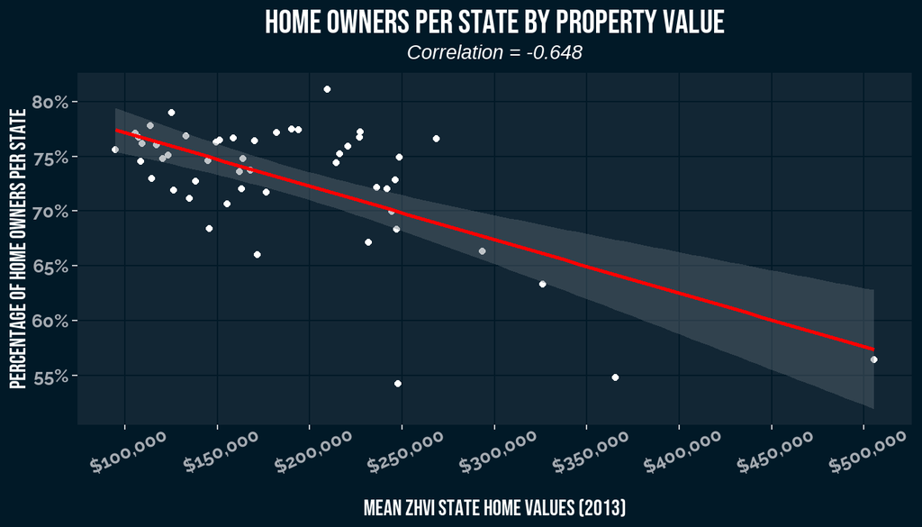

```r
state_own %>% ggplot(aes(x = value, y = pc)) +
  geom_point() +
  geom_smooth(color = "red", method = "lm") +
  scale_x_continuous(labels = scales::dollar_format(),
                     breaks = c(100000, 150000, 200000, 250000, 300000, 350000, 400000, 450000, 500000)) +
  scale_y_continuous(labels = scales::percent_format(),
                    breaks = c(.55, .6, .65, .7, .75, .8)) +
  labs(title = "Home Owners per State by Property Value",
       subtitle = paste0("Correlation = ", round(cor(state_own$value, state_own$pc), 3))) +
  xlab("Mean ZHVI State Home Values (2013)") +
  ylab("Percentage of Home Owners Per State") +
  theme(panel.grid.minor = element_blank(),
        plot.title = element_text(face = "bold", size = 18, hjust = 0.5, family = "bebas neue"),
        plot.subtitle = element_text(face = "italic", hjust = 0.5),
        axis.title = element_text(face = "bold", size = 12, family = "bebas neue"),
        axis.text = element_text(face = "bold", size = 10, family = "raleway"),
        axis.text.x = element_text(margin = margin(t = 8), angle = 25))
```

> - According to the amount of home owners in the `brfss2013` survey, there is a far higher concentration of home owners in states that are more affordable. Remembering that the percentage of home owners was calculated from number of respondents for each state implies that the total number of surveys in each state most likely does not effect these results.
> - Since mostly home owners were interviewed, the y-axis fully above 50% is not meaningful so we are more concerned with the *change* in y values along the property value levels (the slope).

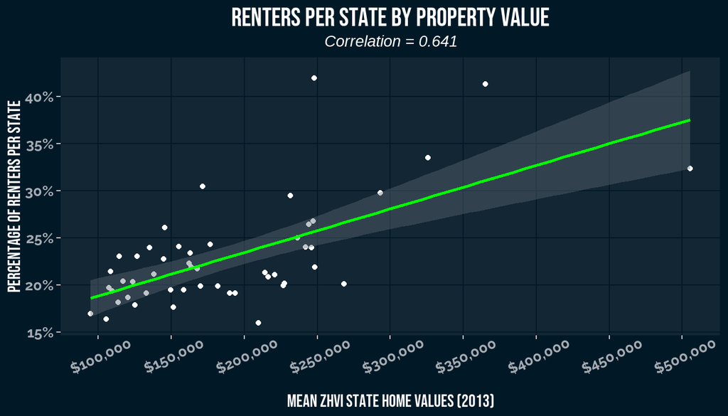

```r
state_rent %>% ggplot(aes(x = value, y = pc)) +
  geom_point() +
  geom_smooth(color = "green", method = "lm")+
  scale_x_continuous(labels = scales::dollar_format(),
                     breaks = seq(100000, 500000, by = 50000)) +
  scale_y_continuous(labels = scales::percent_format()) +
  labs(title = "Renters per State by Property Value",
       subtitle = paste0("Correlation = ", round(cor(state_rent$value, state_rent$pc), 3))) +
  xlab("Mean ZHVI State Home Values (2013)") +
  ylab("Percentage of Renters Per State") +
  theme(panel.grid.minor = element_blank(),
        plot.title = element_text(face = "bold", size = 18, hjust = 0.5, family = "bebas neue"),
        plot.subtitle = element_text(face = "italic", hjust = 0.5),
        axis.title = element_text(face = "bold", size = 12, family = "bebas neue"),
        axis.text = element_text(face = "bold", size = 10, family = "raleway"),
        axis.text.x = element_text(margin = margin(t = 8), angle = 25))
```

> - The x (property) values are still constant so while the dots might appear similar formation, we are still more concerned the degree of *change* in the y values along the x-axis. This time that change (slope) is upward (+0.641) reflecting that property values do influence the amount of renters per state.

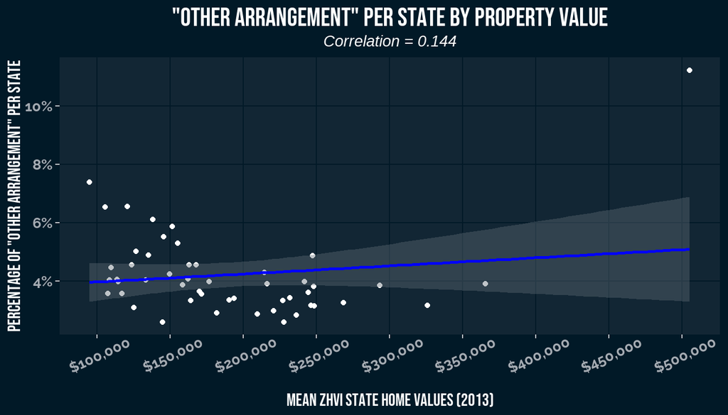

```r
state_other %>% ggplot(aes(x = value, y = pc)) +
  geom_point() +
  geom_smooth(color = "blue", method = "lm")+
  scale_x_continuous(labels = scales::dollar_format(),
                     breaks = seq(100000, 500000, by = 50000)) +
  scale_y_continuous(labels = scales::percent_format()) +
  labs(title = "\"Other Arrangement\" per State by Property Value",
       subtitle = paste0("Correlation = ", round(cor(state_other$value, state_other$pc), 3))) +
  xlab("Mean ZHVI State Home Values (2013)") +
  ylab("Percentage of \"Other Arrangement\" Per State") +
  theme(panel.grid.minor = element_blank(),
        plot.title = element_text(face = "bold", size = 18, hjust = 0.5, family = "bebas neue"),
        plot.subtitle = element_text(face = "italic", hjust = 0.5),
        axis.title = element_text(face = "bold", size = 12, family = "bebas neue"),
        axis.text = element_text(face = "bold", size = 10, family = "raleway"),
        axis.text.x = element_text(margin = margin(t = 8), angle = 25))
```

> - Again remembering that the “other arrangement” response is an ambiguous class of home residence status and considering this response was less than 5% this analysis will not hold as much weight at the prior two but we must still interpret the results.
> - The misleading nature of the linear regression line here must be noted. If Hawaii (the only point above $400,000) were excluded, this line would show a negative correlation in “other arrangement” responses.

## Research Question 3

**Which states have poor seat belt habits and do they correlate to states with higher vehicle fatalities?**

*Limitations: Total number of adults over 18 per state **(what was calculated)**, is not the same as number of eligible licensed drivers per state **(what could not be obtained)**.*

### EDA

#### Additional Data

In addition to the `seatbelt` responses in the `BRFSS2013` data, we will need to bring in 3 more data sets.

1. `FARS2013` - The [Fatality Analysis Reporting System](https://crashstats.nhtsa.dot.gov/Api/Public/ViewPublication/813254) is a database provided by the National Highway Traffic Safety Administration for data regarding motor vehicle injuries and fatalities.
2. `US_POPULATION_ESTIMATES` - [Yearly State Population Estimates](https://www2.census.gov/programs-surveys/popest/technical-documentation/methodology/2010-2019/natstcopr-methv2.pdf) provided by the United States Census Bureau.
3. `STATE_AGES` - [Population Distribution by Age](https://www.kff.org/other/state-indicator/distribution-by-age/?currentTimeframe=6&sortModel=%7B%22colId%22:%22Location%22,%22sort%22:%22asc%22%7D) is provided by the Kaiser Family Foundation, a nonprofit organization focusing on national health issues, as well as the U.S. role in global health policy.

#### Variables

`X_state`: 51 States (including District of Columbia)

`seatbelt` (transposed): Responses per state; “Always”, “Nearly always”, “Sometimes”, “Seldom”, or “Never”.

`always_pc` (calculated): Percentage of “Always” response per state.

`POPESTIMATE2013`: Total population estimate of each state for 2013.

`Children 0-18`: Percentage of children under 18-years-old per state in 2013.

`adults` (calculated): Total estimated number of adults per state in 2013.

`fatals`: Number of motor vehicle fatalities per state in 2013.

`fatals_permil` (calculated): Motor vehicle fatalities per 1 million adults in each state during 2013.

#### Data Wrangling

Pull the `seatbelt`variable from `brfss2013` and transpose it to get a count of each response per state.

```r
seatbelt <- brfss2013 %>% filter(!X_state %in% c("0", "80", "Puerto Rico", "Guam")) %>%
  group_by(X_state) %>% count(seatbelt) %>%
  filter(!seatbelt %in% c("Never drive or ride in a car", NA)) %>% # Remove non vehicle riders and NA's
  pivot_wider(names_from = seatbelt, values_from = n)

seatbelt %>% head()
```

```
## # A tibble: 6 × 6
## # Groups:   X_state [6]
##   X_state    Always `Nearly always` Never Seldom Sometimes
##   <chr>       <int>           <int> <int>  <int>     <int>
## 1 Alabama      5546             275    67     58       158
## 2 Alaska       3355             436   130     78       196
## 3 Arizona      3383             250    68     31       116
## 4 Arkansas     4035             427    75     61       195
## 5 California   9017             300    77     32       101
## 6 Colorado    10585             992   188    152       360
```

Import and prepare the `FARS2013` data set.

```r
FARS2013 <- read_csv("Data/ACCIDENT.csv")

# Pull STATE & FATALS, group by state and total fatalities per state
FARS2013 <- FARS2013 %>% select(STATE, FATALS) %>%
  group_by(STATE) %>% summarize(fatals = sum(FATALS))

# Pull FIPS code for each state_name
states <- fips_codes %>% select(state_code, state_name) %>%
  mutate(state_code = as.numeric(state_code)) %>%  # Because FARS FIPS were numeric
  unique()

# Join state_name on FIPS & fatalities, then remove FIPS
FARS2013 <- FARS2013 %>% left_join(states, by = c("STATE" = "state_code")) %>% select(-STATE)
```

Retrieve `POPESTIMATE2013` from `US_POPULATION_ESTIMATES` for State Population Estimate from 2013.

```r
# Only pull name of state and 2013 estimate
pop <- read_csv("https://www2.census.gov/programs-surveys/popest/datasets/2010-2019/national/totals/nst-est2019-alldata.csv") %>%
  select(NAME, POPESTIMATE2013)
```

Retrieve `Children 0-18` variable from `STATE_AGES` for each state to calculate number of adults.

```r
download.file("https://docs.google.com/spreadsheets/d/e/2PACX-1vSndFprgfW4wYC9WxGgDuFMR1IeKv1cu3dPdaPtjjAYWFqkrE8sdRHf-iuDWVIEOrIn8jg15qwnfTDm/pub?output=csv",
              destfile = "Data/children.csv")


children <- read_csv("Data/children.csv", skip = 3) %>%
  select(Location, `Children 0-18`)
```

Joining them all together.

```r
# Join `FARS2013` with `pop`
FARS2013 <- FARS2013 %>% left_join(pop, by = c("state_name" = "NAME"))


# Join `FARS2013` with `children`, then calculate number of fatalities per 1 million adults
FARS2013 <- FARS2013 %>% left_join(children, by = c("state_name" = "Location")) %>%
  mutate(adults = round((1 - `Children 0-18`) * POPESTIMATE2013, 0), # Percentage of adults * total estimate
         fatals_permil = round(fatals/adults*1000000, 0)) %>% # Number of fatalities per 1 million adults
  select(-POPESTIMATE2013, -`Children 0-18`) # No longer need estimate or child percentage


# Join `FARS2013` with `seatbelt`, then calculate percentage of "Always" response per state
FARS2013 <- FARS2013 %>%
  left_join(seatbelt, by = c("state_name" = "X_state")) %>%
  group_by(state_name) %>%
  mutate(always_pc = Always/sum(Always, `Nearly always`, Sometimes, Seldom, Never),
         .before = Always)


# Reorder state_name factor levels in ascending fatalities per million
levels <- FARS2013 %>% arrange(fatals_permil) %>% ungroup() %>% pull(state_name) %>% as.factor(.)

FARS2013$state_name <- factor(FARS2013$state_name, levels = levels)

FARS2013 <- FARS2013 %>% rename(state = state_name) # plot_usmap() requires variable to be named `state` or `fips`

FARS2013 %>% head()
```

```
## # A tibble: 6 × 10
## # Groups:   state [6]
##   fatals state       adults fatals_permil always_pc Always `Nearly always` Never
##    <dbl> <fct>        <dbl>         <dbl>     <dbl>  <int>           <int> <int>
## 1    853 Alabama     3.63e6           235     0.909   5546             275    67
## 2     51 Alaska      5.37e5            95     0.800   3355             436   130
## 3    849 Arizona     4.92e6           173     0.879   3383             250    68
## 4    498 Arkansas    2.20e6           226     0.842   4035             427    75
## 5   3107 California  2.86e7           109     0.946   9017             300    77
## 6    482 Colorado    3.95e6           122     0.862  10585             992   188
## # ℹ 2 more variables: Seldom <int>, Sometimes <int>
```

To obtain the centroid locations for all 51 states in this analysis, we will use `usmapdata::centroid_labels()` to plot values on top of a map.

```r
#gg_FARS2013 <- FARS2013 %>% left_join(centroid_labels("states"), by = c("state" = "full")) %>%
#  select(-fips, -abbr) # Remove unnecessary columns provided from centroid_labels()
```

```r
gg_FARS2013 <- FARS2013 %>%
  left_join(centroid_labels("states"), by = c("state" = "full")) %>%
  mutate(geom = str_replace_all(geom, pattern = "[c\\(\\)]", replacement = "")) %>% # Remove 'c()' from the strings
  mutate(geom = str_replace_all(geom, pattern = ",", replacement = " ")) %>% # Replace commas with spaces
  separate(geom, into = c("x", "y"), sep = "\\s+", convert = TRUE) # Separate into x and y, converting to numeric
```

### Plotting with `usmap` Package

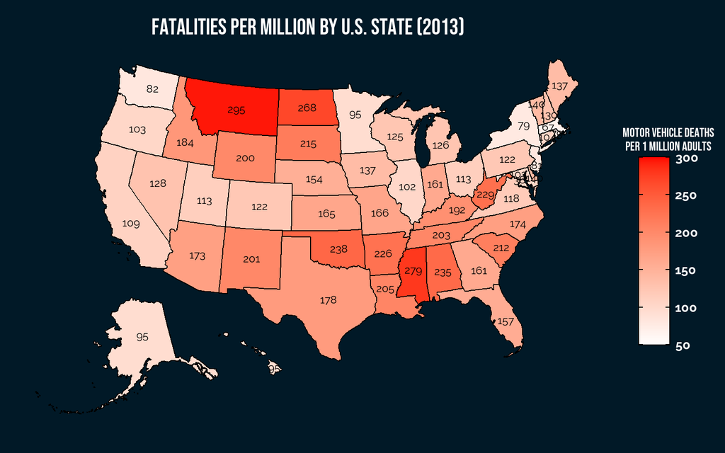

```r
plot_usmap(data = FARS2013, values = "fatals_permil", color = "black") +
  scale_fill_continuous(
    limits = c(50, 300),
    breaks = c(50, 100, 150, 200, 250, 300),
    low = "white", high = "red",
    name = "Motor Vehicle Deaths\nper 1 Million Adults") +
  ggtitle("Fatalities per Million by U.S. State (2013)") +
  theme(plot.title = element_text(family = "bebas neue", color = "white", face = "bold",
                                  size = 18, hjust = 0.5),
        legend.text = element_text(family = "raleway", color = "white", face = "bold", size = 10),
        legend.title = element_text(family = "bebas neue", color = "white", face = "bold",
                                    size = 10, hjust = 0.5, vjust = 1),
        legend.key.height = unit(30, "points"),
        legend.key.width = unit(25, "points"),
        legend.justification = "center",
        legend.position = "right",
        legend.background = element_blank(),
        plot.background = element_blank()) +
  geom_text(aes(x = x, y = y),
            color = "black",
            data = gg_FARS2013,
            label = round(FARS2013$fatals_permil, 0),
            size = 3,
            family = "raleway")
```

> - The highest concentrated regions for fatalities per million adults by state appear in the north mid west and the south.

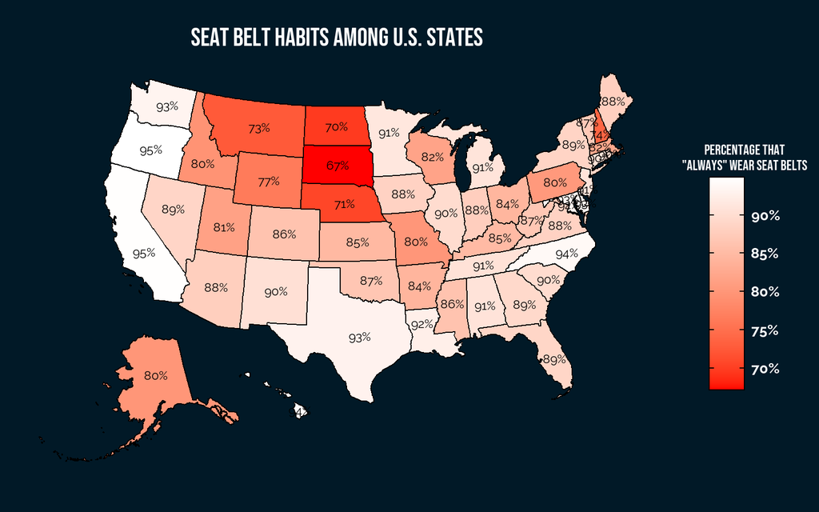

```r
plot_usmap(data = FARS2013, values = "always_pc", color = "black") +
  scale_fill_continuous(
    low = "red", high = "white",
    name = "Percentage That \n\"Always\" Wear Seat Belts",
    label = scales::label_percent()) +
  ggtitle("Seat Belt Habits Among U.S. States") +
  theme(plot.title = element_text(family = "bebas neue", color = "white", face = "bold",
                                  size = 18, hjust = 0.5),
        legend.text = element_text(family = "raleway", color = "white", face = "bold", size = 10),
        legend.title = element_text(family = "bebas neue", color = "white", face = "bold",
                                    size = 10, hjust = 0.5, vjust = 1),
        legend.key.height = unit(30, "points"),
        legend.key.width = unit(25, "points"),
        legend.justification = "center",
        legend.position = "right",
        legend.background = element_blank(),
        plot.background = element_blank())  +
  geom_text(aes(x = x, y = y),
            color = "black",
            data = gg_FARS2013,
            label = paste0(round(FARS2013$always_pc*100,0),"%"),
            size = 3,
            family = "raleway")
```

> - The highest concentrated regions for poor seat belt habits by state appear again in the north mid west and New Hampshire.

### Plotting Fatalities and Seat Belt Habits

Since the north mid west was the only obvious visual comparison among both maps, plot these points on a scatter plot and use the same linear regression line from prior to get a better visual of how these two variables compare.

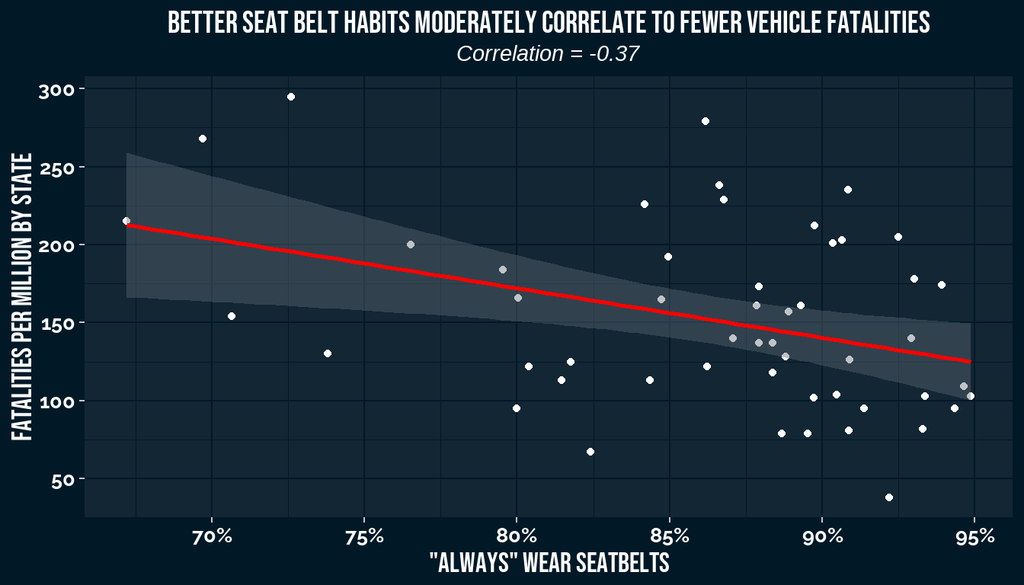

```r
FARS2013 %>% ggplot(aes(x = always_pc, y = fatals_permil)) +
  geom_point() +
  stat_smooth(color = "red", method = lm) +
 # theme_bw() +
  labs(title = "Better Seat Belt Habits Moderately Correlate to Fewer Vehicle Fatalities",
       subtitle = paste0("Correlation = ", round(cor(FARS2013$fatals_permil, FARS2013$always_pc), 3))) +
  xlab("\"Always\" Wear Seatbelts") +
  ylab("Fatalities per Million by State") +
  scale_x_continuous(label = scales::label_percent()) +
  scale_y_continuous(breaks = c(50, 100, 150, 200, 250, 300)) +
  theme(plot.title = element_text(family = "bebas neue", size = 15, face = "bold", hjust = 0.5),
        plot.subtitle = element_text(face = "italic", hjust = 0.5),
        axis.title = element_text(family = "bebas neue", size = 14, face = "bold"),
        axis.text = element_text(family = "raleway", color = "white", size = 10, face = "bold"))
```

> - There is a moderate correlation (-0.37) to fewer vehicle fatalities and better seat belt habits.
> - So wear your seat belts!